# Analisis del salario en Argentina por actividad

Tomás Montemagno

2022-08-07

Al observar la distribución salarial en Argentina por departamento y provincia durante el 2022 notamos como la media salarial es menor en la región noroeste del país, mientras que en la zona pampeana y en el sureste esta media es mayor.

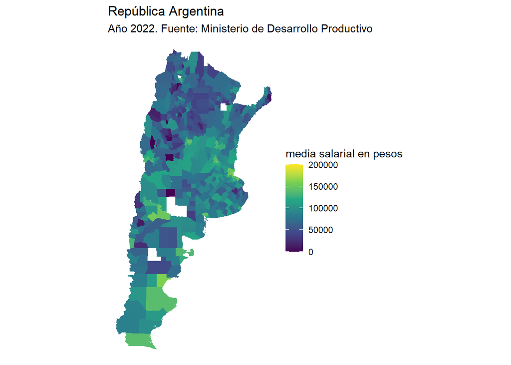

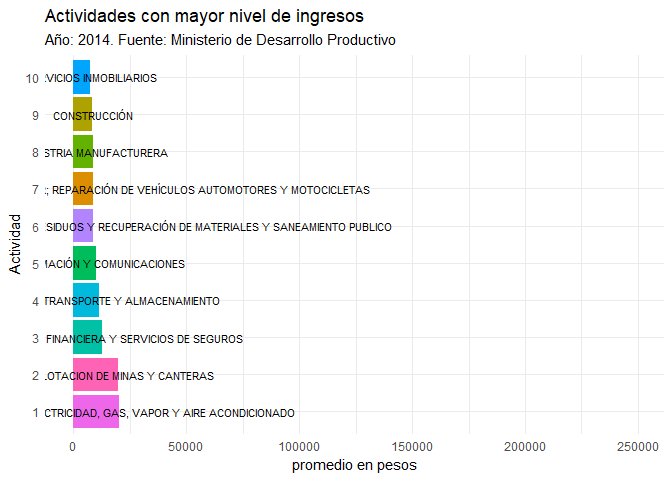

Notamos también que la brecha salarial entre actividades tiene una lógica geográfica. Si observamos la distribución salarial de las actividades de suministro de energía y de explotación de minas y canteras entre provinicas observamos una distribución favorable a la zona sur del país. Estas actividades, al ser las mejores pagas, son las que definen la media salarial de las provincias a nivel país.

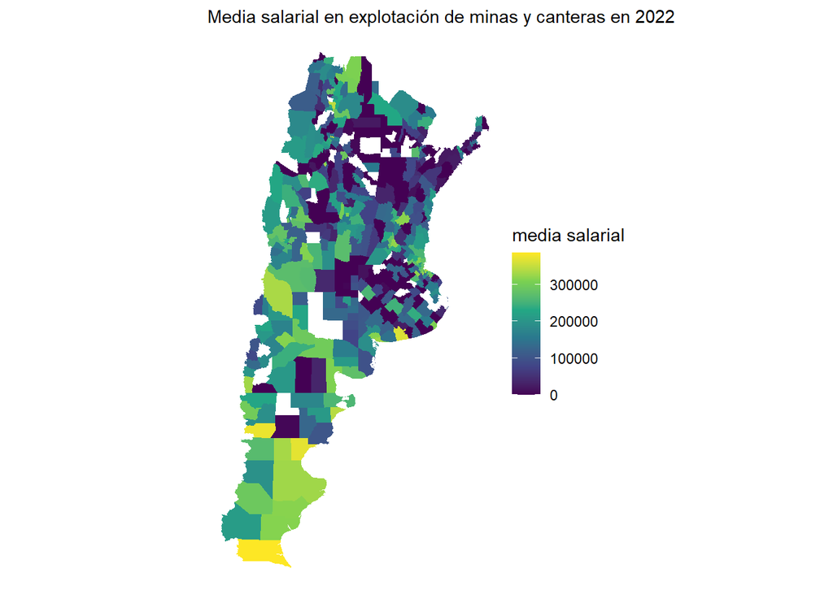

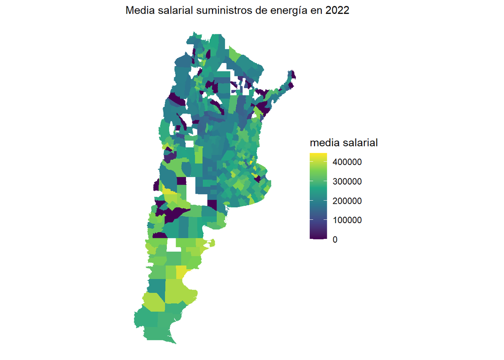

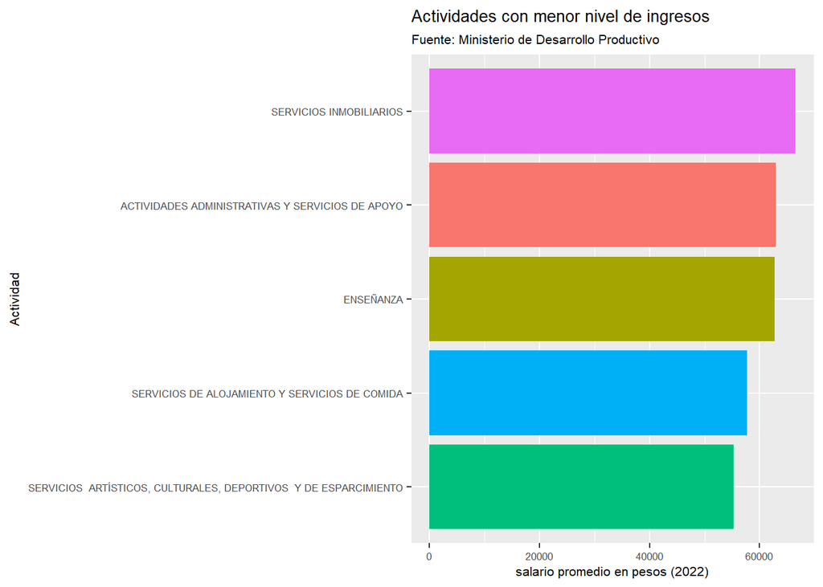

Si comparamos la evolución salarial entre las actividades de suministro de energía y explotación de recursos naturales, con la de enseñanza y servicios artísticos y culturales, observamos como la brecha salarial se acentúa en los últimos años.

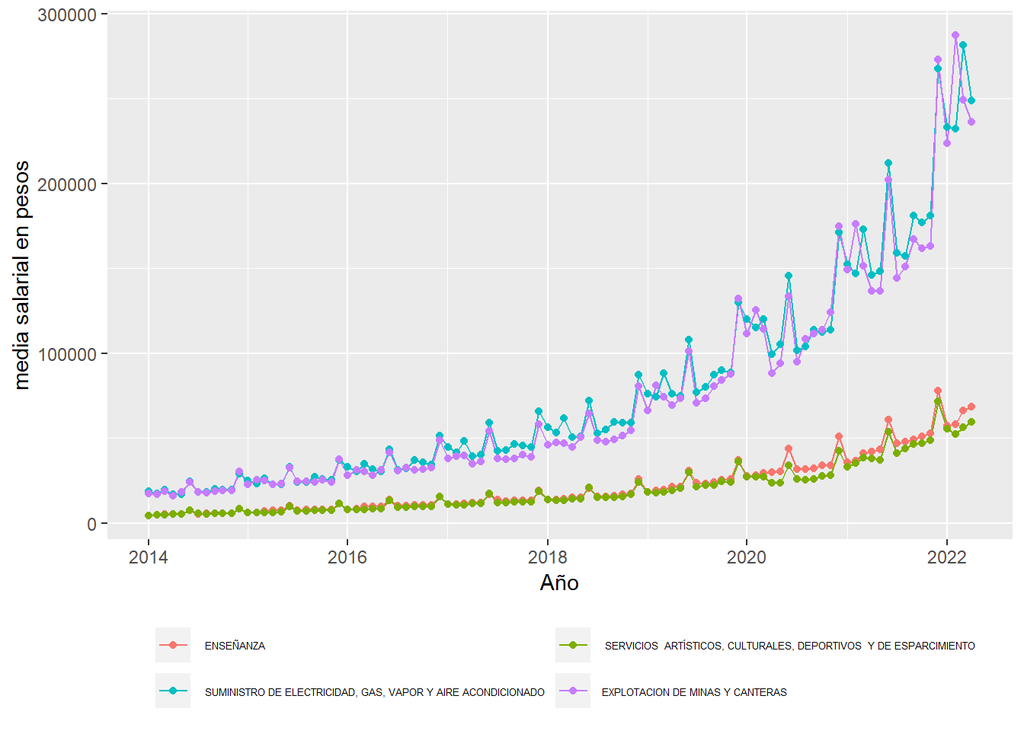

Desde el 2014 al 2022 enseñanza creció la media salarial un 984% y servicios artísticos, culturales y deportivos un 884%. Por otro lado, exlplotación de minas y canterars y suministros de energía 1171% y 1145% respectivamente.

| letra_desc | 2014 | 2022 | Diff |
| --- | --- | --- | --- |
| ENSEÑANZA | 5780.802 | 62686.39 | 984.3892 |
| SERVICIOS ARTÍSTICOS, CULTURALES, DEPORTIVOS Y DE ESPARCIMIENTO | 5685.943 | 55966.48 | 884.2955 |
| SUMINISTRO DE ELECTRICIDAD, GAS, VAPOR Y AIRE ACONDICIONADO | 19980.183 | 248852.66 | 1145.4974 |
| EXPLOTACION DE MINAS Y CANTERAS | 19605.709 | 249174.69 | 1170.9292 |

Este aumento de la brecha entre estas actividades, que se acelera con más fuerza luego del 2019, pudo haberse dado por la pandemia del COVD-19 donde la suspensión clases como de espectáculos golpeó la economía de las actividades enseñanza y Servicios culturales y de esparcimiento.